# Anbefalet af et bildækfirma?!

Den utrolige historie om Michelin

Christian Knudsen

2026-10-18

# Anbefalet af et **bildækfirma?!**

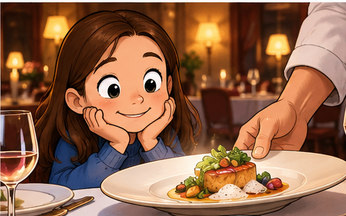

# Vent … hvad har **dæk** med **mad** at gøre?

[figure not shown]

**Michelin** laver dæk.

**Michelin** anbefaler restauranter.

Det er **det samme firma**.

# Spol tilbage til **1889**

[figure not shown]

Biler var **nye og sjældne**.

Ingen GPS. Få værksteder.

To brødre begyndte at lave dæk.

# Problemet: Folk **kørte for lidt**

Dæk slides, når biler kører.

Mere kørsel → mere slid → nye dæk → flere penge

**Hvordan får man folk til at køre mere?**

# En **genialt snedig** idé

[figure not shown]

**Giv folk en god grund til at tage af sted!**

# **1900:** En gratis bog til bilister

[figure not shown]

I bogen stod der, hvor man fandt:

- benzin
- værksteder
- hoteller
- **steder at spise!**

# Tænk, hvis du blev **sulten** på turen …

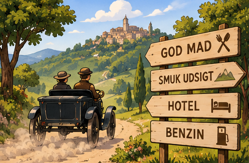

**»Den restaurant ser god ud. Vi kører derhen!«**

# Hvorfor gav de bogen væk **gratis**?

**»Køb vores dæk!«**

*eller …*

**»Her er en nyttig guide til en god ferie!«**

Hvilket firma ville du huske?

# Så begyndte de at **bedømme maden**

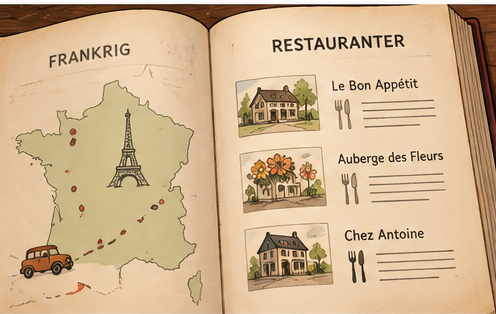

Restauranterne blev vigtigere.

Michelin sendte **anonyme inspektører** ud.

De smagte på maden og vurderede den.

# Og så kom **stjernerne**

**1926** Første stjerner · **1931** Systemet med 1, 2 og 3 stjerner

[figure not shown]

# Ét stop. En omvej. **En hel rejse.**

★

**Én stjerne**Værd at stoppe for

★★

**To stjerner**Værd at køre en omvej for

★★★

**Tre stjerner**Værd at rejse efter

**Det lyder jo stadig som en guide til bilister!**

# Stjerner på **restaurantens dør**

[figure not shown]

**Nu rejste folk efter maden – ikke bare for turens skyld.**

# Et lille ekstra mysterium …

[figure not shown]

**Michelin-manden hedder Bibendum.**

Han er lavet af … **dæk!**

# Tilbage til vores **middag**

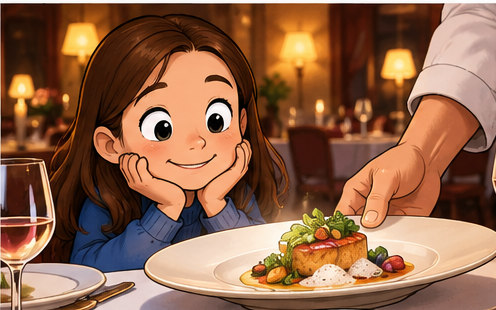

Vi spiste på en restaurant …

… som blev anbefalet af **Michelin** …

… som laver **bildæk**!

# Så … **hvem fandt på det?**

Et **dækfirma**, der gerne ville have folk til at **køre mere**.

**Og idéen virkede så godt, at vi stadig taler om den over 125 år senere.**

# Hvor ved vi det fra?

- [Michelin-guidens officielle historie](https://guide.michelin.com/us/en/about-us)
- [Historien om Michelin-guiden](https://www.michelin.co.uk/blog/articles/history-of-the-michelin-guide)
- [Hvad Michelin-stjernerne betyder](https://intercom.help/michelin-guide-apps/en/articles/8618608-what-are-the-michelin-guide-distinctions)
- [Michelin-mandens historie](https://www.michelin.dk/afsloring-af-michelinmandens-oprindelse-den-ikoniske-maskots-historie)